# FigureYa55plus_pancancer_boxplot

# Academic Citation

If you use this code in your work or research, we kindly request that you cite our publication:

Xiaofan Lu, et al. (2025). FigureYa: A Standardized Visualization Framework for Enhancing Biomedical Data Interpretation and Research Efficiency. iMetaMed. https://doi.org/10.1002/imm3.70005

# 需求描述

# Requirement description

问：FigureYa55pancancer_violin的图能不能画成box plot？

答：可参考FigureYa12box的画法，能让R水平上一个台阶。

问：能不能用FigureYa55pancancer_violin的输出文件easy_input.csv作为输入，直接画出boxplot？想要无缝对接。

答：能。感谢Jiacheng Lou帮忙更新，分享两个版本的解决方案：ggpubr版和纯ggplot2版

Q: Can the figure of FigureYa55pancancer_violin be drawn as a box plot?

A: You can refer to the drawing of FigureYa12box, which can make the R level a step up.

Q：Can I use the output file easy_input.csv of FigureYa55pancancer_violin as input and draw boxplot directly? I want to be seamless.

A: Yes. Thanks to Jiacheng Lou for helping to update and share two versions of the solution: ggpubr version and pure ggplot2 version

# 环境设置

# Environment setting

```r
source("install_dependencies.R")
```

```
## Starting R package installation...
## ===========================================
##
## Installing CRAN packages...
## Package already installed: ggplot2
## Package already installed: ggpubr
##
## ===========================================
## Package installation completed!
## You can now run your R scripts in this directory.
```

```r
Sys.setenv(LANGUAGE = "en") #显示英文报错信息 display English error messages
options(stringsAsFactors = FALSE) #禁止chr转成factor prohibit the conversion of chr to factor
```

# 输入文件

# Input file

easy_input.csv，每行一个sample。第一列组织部位，第二列肿瘤/对照组，第三列基因表达量。

将为每种组织部位计算肿瘤vs.对照之间的p value，在图中用/*标注。

> 怎样获得这个输入文件？

FigureYa55pancancer_violin带你从xena下载数据开始，到提取基因在33种癌症中的表达量。不怕TCGA的normal太少，用GTEx的正常组织作为对照，输出easy_input.csv文件。

easy_input.csv, one sample per row. The first column is the tissue site, the second column is the tumor/control group, and the third column is the gene expression level.

The p value between tumor vs. control will be calculated for each tissue site, marked with /* in the figure.

> How to get this input file?

FigureYa55pancancer_violin takes you from the beginning of the xena download data to extracting gene expression in 33 cancers. Not afraid of too little TCGA normal, use GTEx normal tissue as a control and output the easy_input.csv file.

```r
tcga_gtex <- read.csv("easy_input.csv", row.names = 1, header = T, as.is = F)
head(tcga_gtex)
```

```
##   tissue type2    tpm
## 1    ACC tumor 4.1327
## 2    ACC tumor 4.9519
## 3    ACC tumor 3.0619
## 4    ACC tumor 2.7051
## 5    ACC tumor 1.9749
## 6    ACC tumor 3.1079
```

# 开始画图

# Start drawing

## 方法一：ggpubr

## Method 1: ggpubr

```r
library(ggpubr)
```

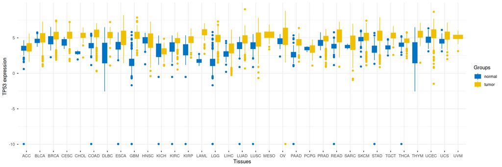

```r
ylabname <- paste("TP53", "expression")
colnames(tcga_gtex) <- c("Tissues", "Groups", "Gene")

p1 <- ggboxplot(tcga_gtex, x = "Tissues", y = "Gene", fill = 'Groups',
                ylab = ylabname,
                color = "Groups", #两组用不同颜色 two groups use different colors
                palette = "jco", #配色方案 color scheme
                ggtheme = theme_minimal())
p1
```

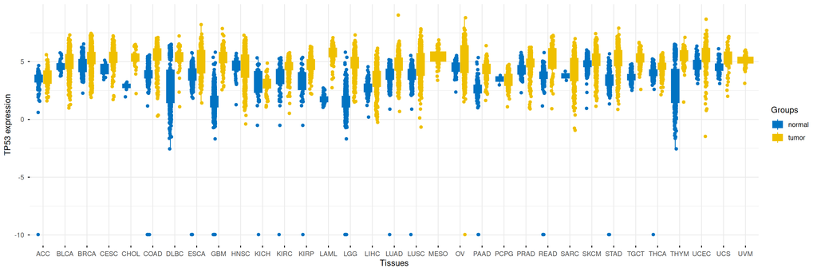

```r
# 画box的同时画散点
# draw the box while drawing the scatter points
p2 <- ggboxplot(tcga_gtex, x = "Tissues", y = "Gene", fill = 'Groups',
                ylab = ylabname,
                color = "Groups",
                palette = "jco",
                add = "jitter", #加散点 add scatter points
                #shape = "Groups", #两组散点用不同形状 two sets of scatter points use different shapes
                ggtheme = theme_minimal())
p2
```

```r
# 标注p value
# mark p value
anno_df <- compare_means(Gene ~ Groups, group.by = "Tissues", data = tcga_gtex,
                         #这里是两组对比，用wilcox.test或t.test
                         #here are two sets of comparisons, using wilcox.test or t.test
                         method = "wilcox.test",
                         #如果多组对比就用下面这行，kruskal.test或anova
                         #if you want to compare multiple groups, use the following line, kruskal.test or anova
                         #method = "kruskal.test",
                         p.adjust.method = "holm") #
head(anno_df)
```

```
## # A tibble: 6 × 9
##   Tissues .y.   group1 group2        p    p.adj p.format p.signif method
##   <fct>   <chr> <chr>  <chr>     <dbl>    <dbl> <chr>    <chr>    <chr>
## 1 ACC     Gene  normal tumor  1.50e- 2 9   e- 2 0.015    *        Wilcoxon
## 2 BLCA    Gene  normal tumor  1.89e- 2 9   e- 2 0.019    *        Wilcoxon
## 3 BRCA    Gene  normal tumor  5.78e-28 1.10e-26 < 2e-16  ****     Wilcoxon
## 4 CESC    Gene  normal tumor  5.85e- 6 4.70e- 5 5.8e-06  ****     Wilcoxon
## 5 CHOL    Gene  normal tumor  1.33e- 5 9.3 e- 5 1.3e-05  ****     Wilcoxon
## 6 COAD    Gene  normal tumor  3.15e-58 9.10e-57 < 2e-16  ****     Wilcoxon
```

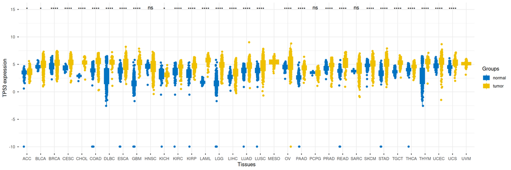

```r
p3 <- p2 +
  stat_pvalue_manual(anno_df, x = "Tissues", y.position = 15,
                     label = "p.signif", position = position_dodge(0.8))
p3
```

```r
ggsave("pancancer_ggpubr.pdf", width = 14, height = 5)
```

## 方法二：ggplot2

## Method 2: ggplot2

用ggplot2自己画，更灵活。

Draw it yourself with ggplot2 for more flexibility.

```r
library(ggplot2)

ylabname <- paste("TP53", "expression")
colnames(tcga_gtex) <- c("Tissues", "Groups", "Gene")

# 剔除没有normal sample的tissue
# exclude tissue without normal sample
tcga_gtex_MESO <- tcga_gtex[tcga_gtex$Tissues=="MESO",]
tcga_gtex_UVM <- tcga_gtex[tcga_gtex$Tissues=="UVM",]
tcga_gtex_withNormal <- tcga_gtex[tcga_gtex$Tissues != "MESO" & tcga_gtex$Tissues != "UVM",]

# 计算p value
# calculate p value
pvalues <- sapply(tcga_gtex_withNormal$Tissues, function(x) {
  res <- wilcox.test(as.numeric(Gene) ~ Groups, data = subset(tcga_gtex_withNormal, Tissues == x)) #两组，wilcox.test或t.test；多组，kruskal.test或aov(one-way ANOVA test) two groups, wilcox.test or t.test; multiple groups, kruskal.test or aov(one-way ANOVA test)
  res$p.value
})
```

[output not shown]

[output cut: 35 more lines]

[output not shown]

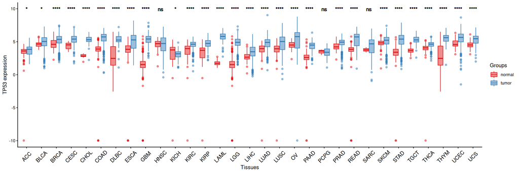

```r
pv <- data.frame(gene = tcga_gtex_withNormal$Tissues, pvalue = pvalues)
pv$sigcode <- cut(pv$pvalue, c(0,0.0001, 0.001, 0.01, 0.05, 1),
                  labels=c('****','***', '**', '*', 'ns'))

# 画box plot
# draw box plot
p.box <- ggplot(tcga_gtex_withNormal, aes(x=Tissues, y=Gene, color=Groups, fill=Groups)) +
  geom_boxplot(alpha = .5) + #半透明 semi-transparent
  theme_classic() + #或theme_bw() or theme_bw()
  scale_fill_brewer(palette = "Set1") + #按类填充颜色 fill color by category
  scale_color_brewer(palette = "Set1") + #按类给边框着色 colorize borders by category

  theme(axis.text.x = element_text(colour="black", size = 11,
                                   #癌症名太挤，旋转45度
                                   #cancer name is too crowded, rotate 45 degrees
                                   angle = 45, hjust = .5, vjust = .5)) +
  geom_text(aes(x=gene, y=max(tcga_gtex_withNormal$Gene) * 1.1,
                         label = pv$sigcode),
                     data=pv,
                     inherit.aes=F) +
  ylab(ylabname)
p.box
```

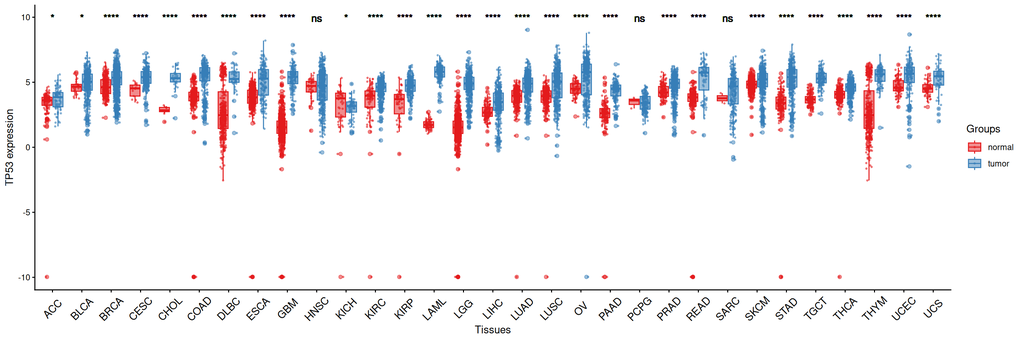

```r
ggsave("pancancer_ggplot2box.pdf", width = 14, height = 5)
# 画带散点的box plot
# draw a box plot with scatter points
p.box.dot <- p.box + geom_point(shape = 21, size=.5, # 点的形状和大小 shape and size of points
             position = position_jitterdodge(), # 让点散开 let the points be scattered
             alpha = .5) #半透明 semi-transparent
p.box.dot
```

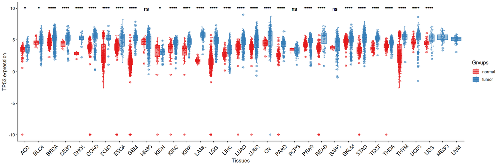

```r
ggsave("pancancer_ggplot2boxDot.pdf", width = 14, height = 5)
# 把不带normal的tissue也画上
# draw the non-normal issue as well
p.box.dot +
  # MESO
  geom_boxplot(alpha = .5, data = tcga_gtex_MESO,
                     mapping = aes(x=Tissues,y=Gene,fill=Groups)) +
  geom_point(data = tcga_gtex_MESO,
                     mapping = aes(x=Tissues,y=Gene,fill=Groups),
             shape = 21, size=.5, # 点的形状和大小 shape and size of points
             position = position_jitterdodge(), # 让点散开 let the points be scattered
             alpha = .5) + #半透明 semi-transparent
  # UVM
  geom_boxplot(alpha = .5, data = tcga_gtex_UVM,
                    mapping = aes(x=Tissues,y=Gene,fill=Groups)) +
  geom_point(data = tcga_gtex_UVM,
                    mapping = aes(x=Tissues,y=Gene,fill=Groups),
             shape = 21, size=.5, # 点的形状和大小 shape and size of points
             position = position_jitterdodge(), # 让点散开 let the points be scattered
             alpha = .5) + #半透明 semi-transparent
  theme_classic() + #或theme_bw() or theme_bw()
  theme(axis.text.x=element_text(colour="black", size = 11,
                                   angle = 45, hjust = .5, vjust = .5))
```

```r
ggsave("pancancer_ggplot2boxDot_all.pdf", width = 14, height = 5)
```

# Session Info

# 会话信息